# Final Project - Plastics

Mary Johnson

22 May, 2020

# Packages and Data

```r
setwd("C:/Users/17155/Documents/Communicating w Graphs")
library(tidyverse)
clrs <- c("Discarded"="#0072B2","Incinerated"="#CC79A7",
          "Recycled"="#009E73")
```

```r
pwp <- read.csv("plastic-waste-polymer.csv")
ppp <- read.csv("plastic-production-polymer.csv")
head(ppp)
```

[output not shown]

# The Fate of Plastics

The following graph shows the percentage of plastic waste that was discarded (in landfills or the environment), incinerated, or recycled from 1980 through 2015. By combining and analyzing data on plastic production, use, and disposal, Geyer et al. (2017) estimated the amount of plastic produced globally during that time period, then calculated the percentage of the plastic waste that was either discarded, incinerated, or recycled. This graph was created to help answer the question: how have plastic disposal methods changed over time?

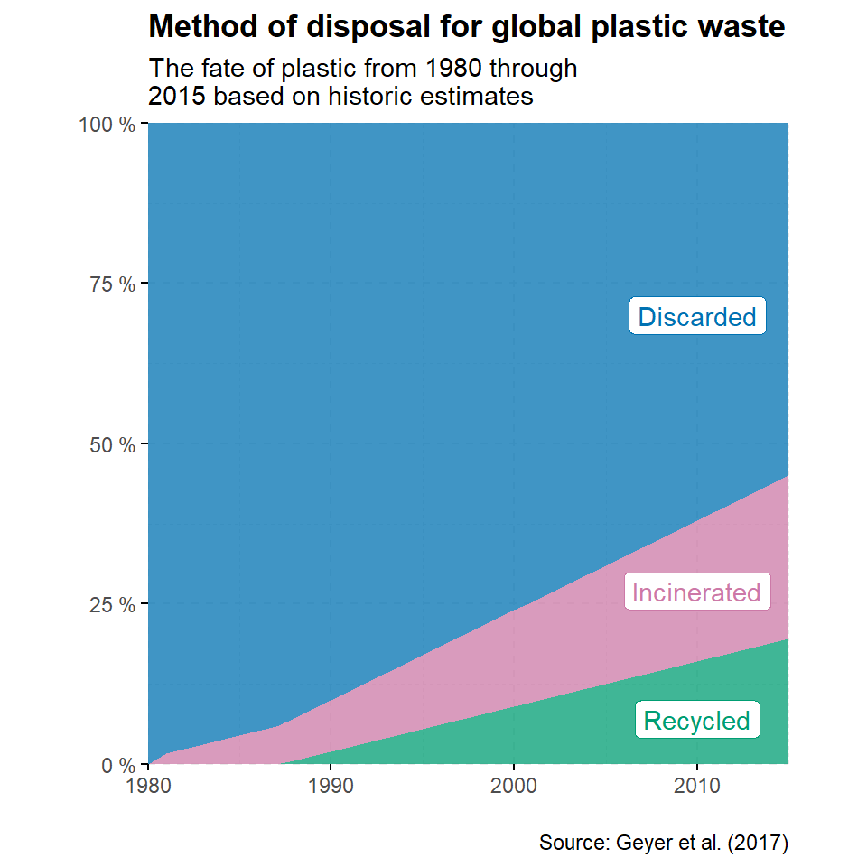

```r
ap <- ggplot(data=gpf,mapping=aes(y=Estimated.historic.plastic.fate....,x=Year,fill=Entity)) +
  geom_area(alpha=0.75) +
  scale_x_continuous(expand=expansion(mult=c(0,0))) +
  scale_y_continuous(expand=expansion(mult=c(0,0)),
        labels=scales::unit_format(unit="%",scale=1/1))  +
  theme_minimal() +
  theme(aspect.ratio=1,axis.title.x=element_blank(),
        axis.title.y=element_blank(),
        legend.position="none",
        axis.ticks=element_line(),
        panel.grid.major=element_line(linetype="dashed"),
        panel.grid.minor=element_line(linetype="dashed"),
        plot.title=element_text(face="bold")) +
  scale_fill_manual(values=clrs) +
  annotate(geom="label",x=2010,y=70,label="Discarded",
           color="#0072B2") +
  annotate(geom="label",x=2010,y=27,label="Incinerated",
           color="#CC79A7") +
  annotate(geom="label",x=2010,y=7,label="Recycled",
           color="#009E73") +
  labs(title="Method of disposal for global plastic waste",
       subtitle=
"The fate of plastic from 1980 through\
2015 based on historic estimates",caption="
       Source: Geyer et al. (2017)")
ap
```

Area charts work well with many dates and are good for showing how values develop over time, so this is a good match for these data. I also chose to make an area chart because it gives a clear representation of the percentages, while also showing the rates of increase in recycling and incineration. I chose to use the colors to clearly differentiate between the different methods of plastic disposal. I made the area chart slightly transparent so the dashed lines would be visible, making it easier to find the percentage of a certain method during a certain year.

# Plastic Production and Plastic Waste by Polymer Type

```r
p4 <- ggplot(data=pwp,mapping=aes(x=Entity,y=Primary.plastic.waste.generation..million.tonnes...tonnes.,fill=Recyclability)) +
  geom_bar(stat="identity",width=0.8,alpha=0.75) +
   scale_x_discrete(expand=expansion(mult=c(0,0))) +
  scale_y_continuous(name="Millions of tons of plastic waste generated",labels=scales::unit_format(unit="million tons",scale=1/1000000),expand=expansion(mult=c(0,0.1))) +
  scale_fill_manual(values=c("#CC79A7","#0072B2","#009E73")) +
  theme_minimal() +
  theme(aspect.ratio=0.55,axis.title.y=element_blank(),
        axis.text.y=element_blank(),
        axis.ticks.x=element_line(),
        axis.text.x=element_text(size=12),
        axis.line.y=element_line(),
        panel.grid.major.y=element_blank(),
        panel.grid.major.x=element_line(linetype="dashed",
                                        color="gray85"),
        panel.grid.minor.x=element_line(linetype="dashed",
                                        color="gray85"),
        legend.key.size=unit(4,units="mm"),
        legend.position=c(1,1),
        legend.justification=c(1,1),
        legend.text=element_text(size=12),
        legend.title=element_blank(),
        panel.background=element_rect(fill="whitesmoke",
                                      color="black"),
        axis.title.x=element_text(size=14,face="bold")) +
  labs(caption=
"
Source: https://ourworldindata.org/") +
  coord_flip()
```

```r
p5 <- ggplot(data=ppp,mapping=aes(x=Entity,y=Primary.plastic.production..million.tonnes...tonnes.,fill=Recyclability)) +
  geom_bar(stat="identity",width=0.8,alpha=0.75) +
  scale_x_discrete(expand=expansion(mult=c(0,0))) +
  scale_y_continuous(name="Millions of tons of plastic produced",labels=scales::unit_format(unit="million tons",scale=1/1000000),expand=expansion(mult=c(0,0.1))) +
  scale_fill_manual(values=c("#CC79A7","#0072B2","#009E73")) +
  theme_minimal() +
  theme(aspect.ratio=0.55,
        axis.title.y=element_blank(),
        axis.ticks.x=element_line(),
        axis.title.x=element_text(size=14,face="bold"),
        axis.text.x=element_text(size=12),
        axis.text.y=element_text(size=12),
        axis.line.y=element_line(),
        panel.grid.major.y=element_blank(),
        panel.grid.major.x=element_line(linetype="dashed",
                                        color="gray85"),
        panel.grid.minor.x=element_line(linetype="dashed",
                                        color="gray85"),
        plot.subtitle=element_text(size=14),
        plot.title=element_text(size=18,face="bold"),
        legend.position="none",
        panel.background=element_rect(fill="whitesmoke",
                                      color="black")) +
  labs(title="Global primary plastic production and plastic waste generated in 2015",
       subtitle=
"Organized by polymer type: polymer types are PVC (polyvinyl chloride); PUT (polyurethanes);\
PS (polystyrene); PP&A fibers (polyphthalamide fibers), PP (polypropylene); PET (polyethylene\
terephthalate); LDPE (low-density polyethylene); HDPE (high-density polyethylene)
") +
  coord_flip()
```

The following figure shows two different plots. The plot on the left shows millions of tons of plastic produced globally during 2015, organized by the types of polymers produced. The plot on the right shows millions of tons of plastic waste produced globally during 2015, organized by the type of polymer. The data includes 9 different types of polymers (plastics). The data represents only primary plastics, or plastics made from virgin materials, meaning that all plastics represented in these plots were made from petroleum and not recycled material. The data also includes the recyclability of each type of polymer. This figure was created to help answer the questions: what is the most-produced polymer, how does polymer production relate to polymer waste generated, and if a polymer is widely recycled, will its production from virgin materials be lower than sometimes recycled and non-recyclable plastics?

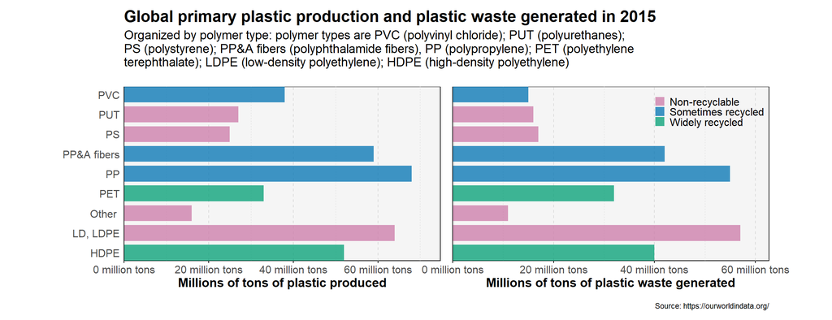

```r
pp <- p5
pw <- p4

library(patchwork)
pp + pw
```

These plots show that polypropylene, and low-density polyethylene, and polyphthalamide fibers (in that order), are the most-produced polymers, and that they are also the three polymer types that generated the most plastic waste. These plots show that the millions of tons of a polymer produced in a year is pretty close to the millions of tons of waste generated by that polymer in the same year, which exemplifies how plastics are typically used once and then disposed of. These plots also show that polyethylene terephthalate, in the widely recycled category, was produced less than all sometimes recycled plastics, but more than most non-recyclable plastics. This suggests that despite it being widely recyclable, polyethylene terephthalate is still produced by virgin materials more than most non-recyclable plastics are, likely because it is more commonly used.

I chose to make bar plots with these data because the bar plots clearly show the amounts produced for each category (type of polymer), and because I could color-code the bars for each type of polymer based on their recyclability. I made the panel background slightly darker so that each plot would stand out from the rest of the figure. I put them side-by-side so the length of the bars could be easily compared. I made the bars slightly transparent to make finding the values that line up with the dashed lines easier.